# Machine Learning Course Project

Jerry

December 21, 2016

Synopsis : This report detailed below is for the final project that we had to present for the Practical Machine Learning Class.

Using devices such as Jawbone Up, Nike FuelBand, and Fitbit it is now possible to collect a large amount of data about personal activity relatively inexpensively. These type of devices are part of the quantified self movement - a group of enthusiasts who take measurements about themselves regularly to improve their health, to find patterns in their behavior, or because they are tech geeks. One thing that people regularly do is quantify how much of a particular activity they do, but they rarely quantify how well they do it

Purpose of the Project :

Data Preprocessing and Exploration :

Reading the data and carrying out some basic data exploration.

```r
library(caret)#loading all required libraries .
library(ggplot2)
library(rattle)
library(rpart)
library(rpart.plot)
library(randomForest)
library(corrplot)
library(gbm)
library(plyr)
library(splines)
TestData <- read.csv ("pml-testing.csv")
TrainData <- read.csv ("pml-training.csv")
dim(TrainData)
```

```
## [1] 19622   160
```

```r
dim(TestData)
```

```
## [1]  20 160
```

The summary and str commands were run on the Train Set and we noticed that the data frame consisted of 160 variables and 19622 observations. However a large number of variables comprised mainy of NA’s (Garbage Variables).

We now go ahead and remove the Garbage Values and use only variables that we need.

```r
TrainTidy <- TrainData[,-c(grep("^amplitude|^kurtosis|^skewness|^avg|^cvtd_timestamp|^max|^min|^new_window|^raw_timestamp|^stddev|^var|^user_name|X",names(TrainData)))]
table(complete.cases(TrainTidy))
```

```
##
##  TRUE
## 19622
```

```r
dim(TrainTidy)
```

```
## [1] 19622    54
```

We now have 54 complete variables that we can use for our analysis.

Splitting the Data

I have decided to split the data into Training and Test Data in 60:40 ratio.

```r
set.seed(610)
inTrain <- createDataPartition(y=TrainTidy$classe,
                               p=0.6,list=FALSE)
TidyTrainData <- TrainTidy[inTrain,]
TidyTestData <- TrainTidy[-inTrain,]
```

Model Selection 1.One of the aims of the Project is look out forwhich algorithm suits the data better. 2.The Kappa metric is selected as the comparison criteria. 3.To reduce the risk of overfitting cross validation is employed during model building.

The Random Forest Model

```r
set.seed(610)
controlRF <- trainControl(method="cv", number=3, verboseIter=FALSE)
RandForest <- train(classe ~ ., data=TidyTrainData, method="rf",
                          trControl=controlRF)
RandForest$finalModel
```

```
##
## Call:
##  randomForest(x = x, y = y, mtry = param$mtry)
##                Type of random forest: classification
##                      Number of trees: 500
## No. of variables tried at each split: 27
##
##         OOB estimate of  error rate: 0.3%
## Confusion matrix:
##      A    B    C    D    E class.error
## A 3348    0    0    0    0 0.000000000
## B    7 2267    5    0    0 0.005265467
## C    0    5 2049    0    0 0.002434275
## D    0    0   12 1918    0 0.006217617
## E    0    1    0    5 2159 0.002771363
```

```r
predictRandForest <- predict(RandForest, newdata=TidyTestData)
confMatRandForest <- confusionMatrix(predictRandForest, TidyTestData$classe)
confMatRandForest
```

```
## Confusion Matrix and Statistics
##
##           Reference
## Prediction    A    B    C    D    E
##          A 2231    2    0    0    0
##          B    0 1515    4    0    0
##          C    0    0 1364    7    0
##          D    0    1    0 1278    7
##          E    1    0    0    1 1435
##
## Overall Statistics
##
##                Accuracy : 0.9971
##                  95% CI : (0.9956, 0.9981)
##     No Information Rate : 0.2845
##     P-Value [Acc > NIR] : < 2.2e-16
##
##                   Kappa : 0.9963
##  Mcnemar's Test P-Value : NA
##
## Statistics by Class:
##
##                      Class: A Class: B Class: C Class: D Class: E
## Sensitivity            0.9996   0.9980   0.9971   0.9938   0.9951
## Specificity            0.9996   0.9994   0.9989   0.9988   0.9997
## Pos Pred Value         0.9991   0.9974   0.9949   0.9938   0.9986
## Neg Pred Value         0.9998   0.9995   0.9994   0.9988   0.9989
## Prevalence             0.2845   0.1935   0.1744   0.1639   0.1838
## Detection Rate         0.2843   0.1931   0.1738   0.1629   0.1829
## Detection Prevalence   0.2846   0.1936   0.1747   0.1639   0.1832
## Balanced Accuracy      0.9996   0.9987   0.9980   0.9963   0.9974
```

The Random Forest model has a accuracy of 0.9971 and Kappa Value of 0.9963

The Decision Tree Method

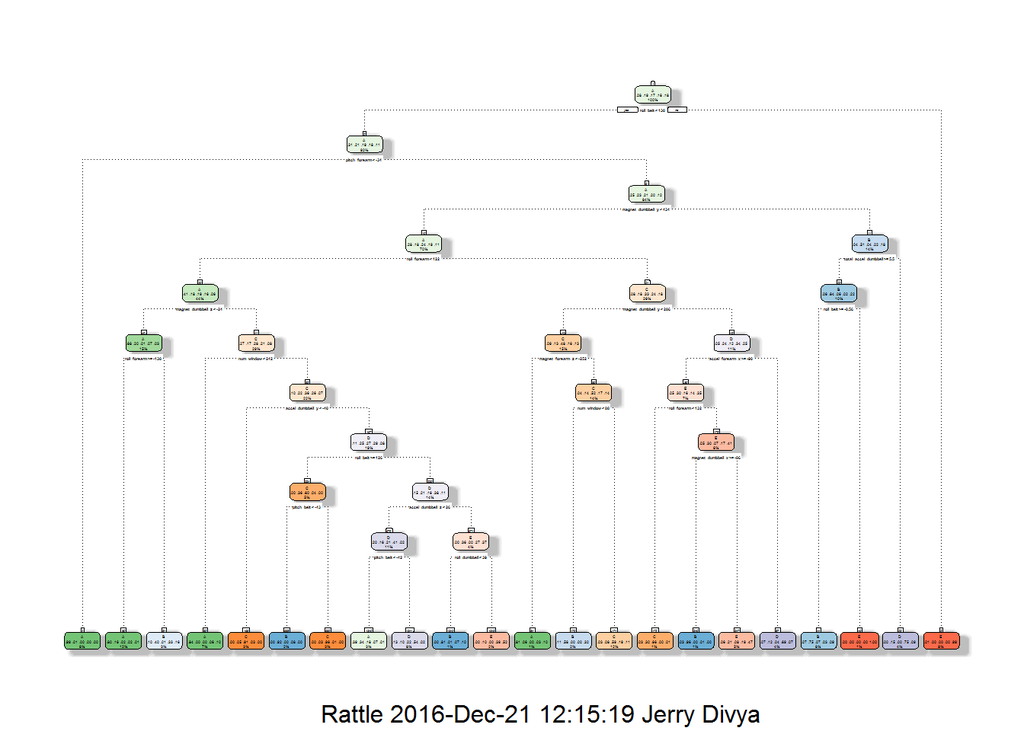

```r
set.seed(610)
FitDecTree <- rpart(classe ~ ., data=TidyTrainData, method="class")
fancyRpartPlot(FitDecTree)
```

```r
predictDecTree <- predict(FitDecTree, newdata=TidyTestData, type="class")
confMatDecTree <- confusionMatrix(predictDecTree, TidyTestData$classe)
confMatDecTree
```

```
## Confusion Matrix and Statistics
##
##           Reference
## Prediction    A    B    C    D    E
##          A 1981  258   65   84   67
##          B   77  877   53  101  147
##          C   25  107 1073  184  106
##          D  115  156  139  783   79
##          E   34  120   38  134 1043
##
## Overall Statistics
##
##                Accuracy : 0.7337
##                  95% CI : (0.7238, 0.7435)
##     No Information Rate : 0.2845
##     P-Value [Acc > NIR] : < 2.2e-16
##
##                   Kappa : 0.6622
##  Mcnemar's Test P-Value : < 2.2e-16
##
## Statistics by Class:
##
##                      Class: A Class: B Class: C Class: D Class: E
## Sensitivity            0.8875   0.5777   0.7844   0.6089   0.7233
## Specificity            0.9156   0.9403   0.9349   0.9255   0.9491
## Pos Pred Value         0.8069   0.6988   0.7177   0.6156   0.7619
## Neg Pred Value         0.9534   0.9027   0.9536   0.9235   0.9384
## Prevalence             0.2845   0.1935   0.1744   0.1639   0.1838
## Detection Rate         0.2525   0.1118   0.1368   0.0998   0.1329
## Detection Prevalence   0.3129   0.1600   0.1905   0.1621   0.1745
## Balanced Accuracy      0.9016   0.7590   0.8596   0.7672   0.8362
```

The Decision Tress has a accuracy of 0.7337 and a Kappa Value of 0.66

The Generalized Boost Method

```r
set.seed(610)
controlGBM <- trainControl(method = "repeatedcv", number = 5, repeats = 1)
FitGBM  <- train(classe ~ ., data=TidyTrainData, method = "gbm",
                    trControl = controlGBM, verbose = FALSE)
FitGBM$finalModel
```

```
## A gradient boosted model with multinomial loss function.
## 150 iterations were performed.
## There were 53 predictors of which 41 had non-zero influence.
```

```r
predictGBM <- predict(FitGBM, newdata=TidyTestData)
confMatGBM <- confusionMatrix(predictGBM, TidyTestData$classe)
confMatGBM
```

```
## Confusion Matrix and Statistics
##
##           Reference
## Prediction    A    B    C    D    E
##          A 2228   11    0    1    2
##          B    4 1492   15    2   10
##          C    0   12 1350   16    3
##          D    0    3    1 1267   19
##          E    0    0    2    0 1408
##
## Overall Statistics
##
##                Accuracy : 0.9871
##                  95% CI : (0.9844, 0.9895)
##     No Information Rate : 0.2845
##     P-Value [Acc > NIR] : < 2.2e-16
##
##                   Kappa : 0.9837
##  Mcnemar's Test P-Value : NA
##
## Statistics by Class:
##
##                      Class: A Class: B Class: C Class: D Class: E
## Sensitivity            0.9982   0.9829   0.9868   0.9852   0.9764
## Specificity            0.9975   0.9951   0.9952   0.9965   0.9997
## Pos Pred Value         0.9938   0.9796   0.9776   0.9822   0.9986
## Neg Pred Value         0.9993   0.9959   0.9972   0.9971   0.9947
## Prevalence             0.2845   0.1935   0.1744   0.1639   0.1838
## Detection Rate         0.2840   0.1902   0.1721   0.1615   0.1795
## Detection Prevalence   0.2858   0.1941   0.1760   0.1644   0.1797
## Balanced Accuracy      0.9979   0.9890   0.9910   0.9909   0.9881
```

The GBM Method has a accuracy of 0.9871 and a kappa value of 0.9837

Final Model Testing

Finally we test the Random Forest Model on the Test data to predict the 20 values that we need for the next quiz

```r
predictTEST <- predict(RandForest, newdata=TestData)
predictTEST
```

```
##  [1] B A B A A E D B A A B C B A E E A B B B
## Levels: A B C D E
```